# Assessment 04 - Statistical Model

Gabriele Mineo - Harvard Data Science Professional

## **Heights Revisited**

We have been using urn models to motivate the use of probability models. However, most data science applications are not related to data obtained from urns. More common are data that come from individuals. Probability plays a role because the data come from a random sample. The random sample is taken from a population and the urn serves as an analogy for the population.

Let’s revisit the heights dataset. For now, consider `x` to be the heights of all males in the data set. Mathematically speaking, `x` is our population. Using the urn analogy, we have an urn with the values of `x` in it.

What are the population average and standard deviation of our population?

Instructions

- Execute the lines of code that create a vector `x` that contains heights for all males in the population.
- Calculate the average of `x`.
- Calculate the standard deviation of `x`.

```r
# Load the 'dslabs' package and data contained in 'heights'
library(dslabs)
library(dplyr)
data(heights)

# Make a vector of heights from all males in the population
x <- heights %>% filter(sex == "Male") %>%
  .$height

# Calculate the population average. Print this value to the console.
mean(x)
```

```
## [1] 69.31475
```

```r
# Calculate the population standard deviation. Print this value to the console.
sd(x)
```

```
## [1] 3.611024
```

## **Sample the population of heights**

Call the population average computed above μ and the standard deviation σ. Now take a sample of size 50, with replacement, and construct an estimate for μ and σ.

Instructions

- Use the `sample` function to sample `N` values from `x`.
- Calculate the mean of the sampled heights.
- Calculate the standard deviation of the sampled heights.

```r
# The vector of all male heights in our population `x` has already been loaded for you. You can examine the first six elements using `head`.
head(x)
```

```
## [1] 75 70 68 74 61 67
```

```r
# Use the `set.seed` function to make sure your answer matches the expected result after random sampling
set.seed(1)

# Define `N` as the number of people measured
N <- 50

# Define `X` as a random sample from our population `x`
X <- sample(x, N, replace = TRUE)

# Calculate the sample average. Print this value to the console.
mean(X)
```

```
## [1] 68.73423
```

```r
# Calculate the sample standard deviation. Print this value to the console.
sd(X)
```

```
## [1] 3.761344
```

## **Sample and Population Averages**

What does the central limit theory tell us about the sample average and how it is related to μ, the population average?

Possible Answers

- It is identical to μ.
- It is a random variable with expected value μ and standard error $\ \sigma/\sqrt{N}$. [X]
- It is a random variable with expected value μ and standard error σ.
- It underestimates μ.

## **Confidence Interval Calculation**

We will use $\ \bar{X}$ as our estimate of the heights in the population from our sample size N. We know from previous exercises that the standard estimate of our error $\ \bar{X}-\mu$ is $\ \sigma/\sqrt{N}$.

Construct a 95% confidence interval for μ.

Instructions

- Use the `sd` and `sqrt` functions to define the standard error `se`
- Calculate the 95% confidence intervals using the `qnorm` function. Save the lower then the upper confidence interval to a variable called `ci`.

```r
# The vector of all male heights in our population `x` has already been loaded for you. You can examine the first six elements using `head`.
head(x)
```

```
## [1] 75 70 68 74 61 67
```

```r
# Use the `set.seed` function to make sure your answer matches the expected result after random sampling
set.seed(1)

# Define `N` as the number of people measured
N <- 50

# Define `X` as a random sample from our population `x`
X <- sample(x, N, replace = TRUE)

# Define `se` as the standard error of the estimate. Print this value to the console.
X_hat <- mean(X)
se_hat <- sd(X)
se <- se_hat / sqrt(N)
se
```

```
## [1] 0.5319343
```

```r
# Construct a 95% confidence interval for the population average based on our sample. Save the lower and then the upper confidence interval to a variable called `ci`.
ci <- c(qnorm(0.025, mean(X), se), qnorm(0.975, mean(X), se))
```

## **Monte Carlo Simulation for Heights**

Now run a Monte Carlo simulation in which you compute 10,000 confidence intervals as you have just done. What proportion of these intervals include μ?

Instructions

- Use the `replicate` function to replicate the sample code for `B <- 10000` simulations. Save the results of the replicated code to a variable called `res`. The replicated code should complete the following steps: -1. Use the `sample` function to sample `N` values from `x`. Save the sampled heights as a vector called `X`. -2. Create an object called `interval` that contains the 95% confidence interval for each of the samples. Use the same formula you used in the previous exercise to calculate this interval. -3. Use the `between` function to determine if μ is contained within the confidence interval of that simulation.
- Finally, use the `mean` function to determine the proportion of results in `res` that contain mu.

```r
# Define `mu` as the population average
mu <- mean(x)

# Use the `set.seed` function to make sure your answer matches the expected result after random sampling
set.seed(1)

# Define `N` as the number of people measured
N <- 50

# Define `B` as the number of times to run the model
B <- 10000

# Define an object `res` that contains a logical vector for simulated intervals that contain mu
res <- replicate(B, {
  X <- sample(x, N, replace = TRUE)
  X_hat <- mean(X)
  se_hat <- sd(X)
  se <- se_hat / sqrt(N)
  interval <- c(qnorm(0.025, mean(X), se) , qnorm(0.975, mean(X), se))
  between(mu, interval[1], interval[2])
})

# Calculate the proportion of results in `res` that include mu. Print this value to the console.
mean(res)
```

```
## [1] 0.9433
```

## **Visualizing Polling Bias**

In this section, we used visualization to motivate the presence of pollster bias in election polls. Here we will examine that bias more rigorously. Lets consider two pollsters that conducted daily polls and look at national polls for the month before the election.

Is there a poll bias? Make a plot of the spreads for each poll.

Instructions

- Use `ggplot` to plot the spread for each of the two pollsters.
- Define the x- and y-axes usingusing `aes()` within the `ggplot` function.
- Use `geom_boxplot` to make a boxplot of the data.
- Use `geom_point` to add data points to the plot.

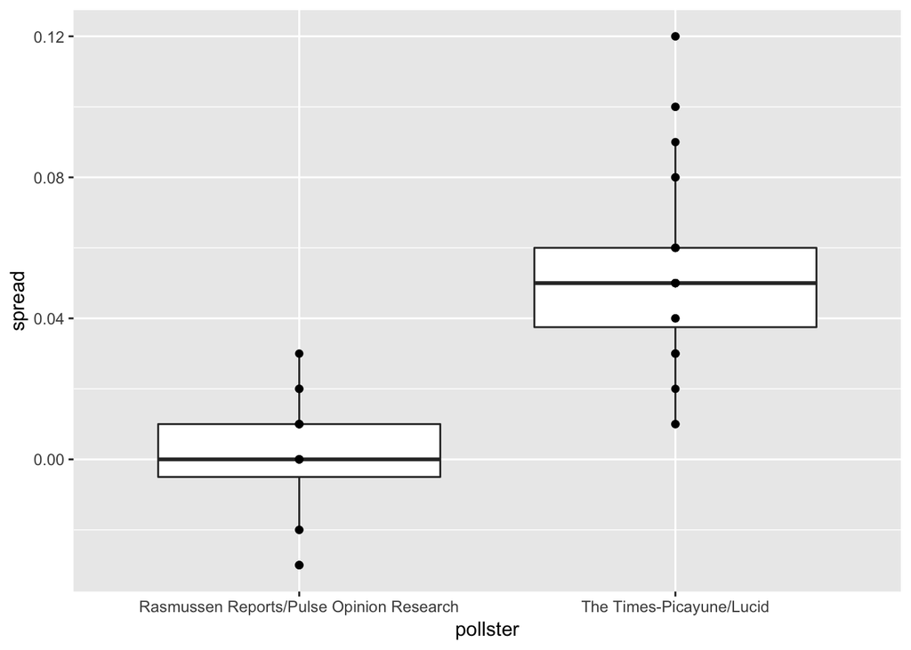

```r
# Load the libraries and data you need for the following exercises
library(dslabs)
library(dplyr)
library(ggplot2)
data("polls_us_election_2016")

# These lines of code filter for the polls we want and calculate the spreads
polls <- polls_us_election_2016 %>%
  filter(pollster %in% c("Rasmussen Reports/Pulse Opinion Research","The Times-Picayune/Lucid") &
           enddate >= "2016-10-15" &
           state == "U.S.") %>%
  mutate(spread = rawpoll_clinton/100 - rawpoll_trump/100)

# Make a boxplot with points of the spread for each pollster
polls %>% ggplot(aes(pollster, spread)) + geom_boxplot() + geom_point()
```

## **Defining Pollster Bias**

The data do seem to suggest there is a difference between the pollsters. However, these data are subject to variability. Perhaps the differences we observe are due to chance. Under the urn model, both pollsters should have the same expected value: the election day difference, $\ d$.

We will model the observed data Yij in the following way:

$\ Y_{ij} = d + b_i + \varepsilon_{ij}$

with $\ i=1,2$ indexing the two pollsters, bi the bias for pollster $\ i$, and $\ ε_{ij}$ poll to poll chance variability. We assume the ε are independent from each other, have expected value 0 and standard deviation $\ σ_i$ regardless of $\ j$.

Which of the following statements best reflects what we need to know to determine if our data fit the urn model?

Possible Answers

- Is $\ εij=0$?
- How close are $\ Y_{ij}$ to $\ d$?
- Is $\ b1≠b2?$ [X]
- Are $\ b1=0$ and $\ b2=0$?

## **Derive Expected Value**

We modelled the observed data $\ Y_{ij}$ as:

$\ Y_{ij} = d + b_i + \varepsilon_{ij}$

On the right side of this model, only $\ εij$ is a random variable. The other two values are constants.

What is the expected value of $\ Y_{ij}$?

Possible Answers

- $\ d+b_1$ [X]
- $\ b_1 + \varepsilon_{ij}$
- $\ d$
- $\ d + b_1 + \varepsilon_{ij}$

## **Expected Value and Standard Error of Poll 1**

Suppose we define $\ \bar{Y}_1$ as the average of poll results from the first poll and σ1 as the standard deviation of the first poll.

What is the expected value and standard error of $\ \bar{Y}_1$?

Possible Answers

- The expected value is $\ d+b1$ and the standard error is $\ σ1$
- The expected value is $\ d$ and the standard error is $\ \sigma_1/\sqrt{N_1}$
- The expected value is $\ d+b1$ and the standard error is $\ \sigma_1/\sqrt{N_1}$ [X]
- The expected value is $\ d$ and the standard error is $\ \sigma_1+\sqrt{N_1}$

## **Expected Value and Standard Error of Poll 2**

Now we define $\ \bar{Y}_2$ as the average of poll results from the second poll.

What is the expected value and standard error of $\ \bar{Y}_2$?

Possible Answers

- The expected value is $\ d+b_2$ and the standard error is $\ σ2$
- The expected value is $\ d$ and the standard error is $\ \sigma_2/\sqrt{N_2}$
- The expected value is $\ d+b_2$ and the standard error is $\ \sigma_2/\sqrt{N_2}$ [X]
- The expected value is $\ d$ and the standard error is $\ \sigma_2 + \sqrt{N_2}$

## **Difference in Expected Values Between Polls**

Using what we learned by answering the previous questions, what is the expected value of $\ \bar{Y}_2 - \bar{Y}_1$?

Possible Answers

- $\ (b_2 - b_1)^2$
- $\ b_2 - b_1/\sqrt(N)$
- $\ b_2 + b_1$
- $\ b_2 - b_1$ [X]

## **Standard Error of the Difference Between Polls**

Using what we learned by answering the questions above, what is the standard error of $\ \bar{Y}_2 - \bar{Y}_1$?

Possible Answers

- $\ \sqrt{\sigma_2^2/N_2 + \sigma_1^2/N_1}$ [X]
- $\ \sqrt{\sigma_2/N_2 + \sigma_1/N_1}$
- $\ (\sigma_2^2/N_2 + \sigma_1^2/N_1)^2$
- $\ \sigma_2^2/N_2 + \sigma_1^2/N_1$

## **Compute the Estimates**

The answer to the previous question depends on $\ σ1$ and $\ σ2$ , which we don’t know. We learned that we can estimate these values using the sample standard deviation.

Compute the estimates of $\ σ1$ and $\ σ2$.

Instructions

- Group the data by pollster.
- Summarize the standard deviation of the spreads for each of the two pollsters.
- Store the pollster names and standard deviations of the spreads (σ) in an object called `sigma`

```r
# The `polls` data have already been loaded for you. Use the `head` function to examine them.
head(polls)
```

```
##   state  startdate    enddate                                 pollster
## 1  U.S. 2016-11-05 2016-11-07                 The Times-Picayune/Lucid
## 2  U.S. 2016-11-02 2016-11-06 Rasmussen Reports/Pulse Opinion Research
## 3  U.S. 2016-11-01 2016-11-03 Rasmussen Reports/Pulse Opinion Research
## 4  U.S. 2016-11-04 2016-11-06                 The Times-Picayune/Lucid
## 5  U.S. 2016-10-31 2016-11-02 Rasmussen Reports/Pulse Opinion Research
## 6  U.S. 2016-11-03 2016-11-05                 The Times-Picayune/Lucid
##   grade samplesize population rawpoll_clinton rawpoll_trump
## 1  <NA>       2521         lv              45            40
## 2    C+       1500         lv              45            43
## 3    C+       1500         lv              44            44
## 4  <NA>       2584         lv              45            40
## 5    C+       1500         lv              42            45
## 6  <NA>       2526         lv              45            40
##   rawpoll_johnson rawpoll_mcmullin adjpoll_clinton adjpoll_trump
## 1               5               NA        45.13966      42.26495
## 2               4               NA        45.56041      43.13745
## 3               4               NA        44.66353      44.28981
## 4               5               NA        45.22830      42.30433
## 5               4               NA        42.67626      45.41689
## 6               5               NA        45.31041      42.34422
##   adjpoll_johnson adjpoll_mcmullin spread
## 1        3.679914               NA   0.05
## 2        4.418502               NA   0.02
## 3        4.331246               NA   0.00
## 4        3.770880               NA   0.05
## 5        4.239500               NA  -0.03
## 6        3.779955               NA   0.05
```

```r
# Create an object called `sigma` that contains a column for `pollster` and a column for `s`, the standard deviation of the spread
polls %>% group_by(pollster)
```

```
## # A tibble: 40 x 16
## # Groups:   pollster [2]
##    state startdate  enddate    pollster grade samplesize population
##    <fct> <date>     <date>     <fct>    <fct>      <int> <chr>
##  1 U.S.  2016-11-05 2016-11-07 The Tim… <NA>        2521 lv
##  2 U.S.  2016-11-02 2016-11-06 Rasmuss… C+          1500 lv
##  3 U.S.  2016-11-01 2016-11-03 Rasmuss… C+          1500 lv
##  4 U.S.  2016-11-04 2016-11-06 The Tim… <NA>        2584 lv
##  5 U.S.  2016-10-31 2016-11-02 Rasmuss… C+          1500 lv
##  6 U.S.  2016-11-03 2016-11-05 The Tim… <NA>        2526 lv
##  7 U.S.  2016-10-27 2016-10-31 Rasmuss… C+          1500 lv
##  8 U.S.  2016-10-30 2016-11-01 Rasmuss… C+          1500 lv
##  9 U.S.  2016-11-02 2016-11-04 The Tim… <NA>        2561 lv
## 10 U.S.  2016-11-01 2016-11-03 The Tim… <NA>        2627 lv
## # ... with 30 more rows, and 9 more variables: rawpoll_clinton <dbl>,
## #   rawpoll_trump <dbl>, rawpoll_johnson <dbl>, rawpoll_mcmullin <dbl>,
## #   adjpoll_clinton <dbl>, adjpoll_trump <dbl>, adjpoll_johnson <dbl>,
## #   adjpoll_mcmullin <dbl>, spread <dbl>
```

```r
sigma <- polls %>% group_by(pollster) %>% summarize(s = sd(spread))

# Print the contents of sigma to the console
sigma
```

```
## # A tibble: 2 x 2
##   pollster                                      s
##   <fct>                                     <dbl>
## 1 Rasmussen Reports/Pulse Opinion Research 0.0177
## 2 The Times-Picayune/Lucid                 0.0268
```

## **Probability Distribution of the Spread**

What does the central limit theorem tell us about the distribution of the differences between the pollster averages, $\ \bar{Y}_2 - \bar{Y}_1$?

Possible Answers

- The central limit theorem cannot tell us anything because this difference is not the average of a sample.
- Because $\ Y_{ij}$ are approximately normal, the averages are normal too.
- If we assume N2 and N1 are large enough, $\ \bar{Y}_2$ and $\ \bar{Y}_1$, and their difference, are approximately normal. [X]
- These data do not contain vectors of 0 and 1, so the central limit theorem does not apply.

## **Calculate the 95% Confidence Interval of the Spreads**

We have constructed a random variable that has expected value $\ b2−b1$, the pollster bias difference. If our model holds, then this random variable has an approximately normal distribution. The standard error of this random variable depends on $\ σ1$ and $\ σ2$, but we can use the sample standard deviations we computed earlier. We have everything we need to answer our initial question: is $\ b2−b1$ different from 0?

Construct a 95% confidence interval for the difference $\ b2$ and $\ b1$. Does this interval contain zero?

Instructions

- Use pipes `%>%` to pass the data `polls` on to functions that will group by pollster and summarize the average spread, standard deviation, and number of polls per pollster.
- Calculate the estimate by subtracting the average spreads.
- Calculate the standard error using the standard deviations of the spreads and the sample size.
- Calculate the 95% confidence intervals using the `qnorm` function. Save the lower and then the upper confidence interval to a variable called `ci`.

```r
# The `polls` data have already been loaded for you. Use the `head` function to examine them.
head(polls)
```

```
##   state  startdate    enddate                                 pollster
## 1  U.S. 2016-11-05 2016-11-07                 The Times-Picayune/Lucid
## 2  U.S. 2016-11-02 2016-11-06 Rasmussen Reports/Pulse Opinion Research
## 3  U.S. 2016-11-01 2016-11-03 Rasmussen Reports/Pulse Opinion Research
## 4  U.S. 2016-11-04 2016-11-06                 The Times-Picayune/Lucid
## 5  U.S. 2016-10-31 2016-11-02 Rasmussen Reports/Pulse Opinion Research
## 6  U.S. 2016-11-03 2016-11-05                 The Times-Picayune/Lucid
##   grade samplesize population rawpoll_clinton rawpoll_trump
## 1  <NA>       2521         lv              45            40
## 2    C+       1500         lv              45            43
## 3    C+       1500         lv              44            44
## 4  <NA>       2584         lv              45            40
## 5    C+       1500         lv              42            45
## 6  <NA>       2526         lv              45            40
##   rawpoll_johnson rawpoll_mcmullin adjpoll_clinton adjpoll_trump
## 1               5               NA        45.13966      42.26495
## 2               4               NA        45.56041      43.13745
## 3               4               NA        44.66353      44.28981
## 4               5               NA        45.22830      42.30433
## 5               4               NA        42.67626      45.41689
## 6               5               NA        45.31041      42.34422
##   adjpoll_johnson adjpoll_mcmullin spread
## 1        3.679914               NA   0.05
## 2        4.418502               NA   0.02
## 3        4.331246               NA   0.00
## 4        3.770880               NA   0.05
## 5        4.239500               NA  -0.03
## 6        3.779955               NA   0.05
```

```r
names(polls)
```

```
##  [1] "state"            "startdate"        "enddate"
##  [4] "pollster"         "grade"            "samplesize"
##  [7] "population"       "rawpoll_clinton"  "rawpoll_trump"
## [10] "rawpoll_johnson"  "rawpoll_mcmullin" "adjpoll_clinton"
## [13] "adjpoll_trump"    "adjpoll_johnson"  "adjpoll_mcmullin"
## [16] "spread"
```

```r
# Create an object called `res` that summarizes the average, standard deviation, and number of polls for the two pollsters.
res <- polls %>% group_by(pollster) %>% summarize(avg=mean(spread), s = sd(spread), N=n())
res
```

```
## # A tibble: 2 x 4
##   pollster                                      avg      s     N
##   <fct>                                       <dbl>  <dbl> <int>
## 1 Rasmussen Reports/Pulse Opinion Research 0.000625 0.0177    16
## 2 The Times-Picayune/Lucid                 0.0529   0.0268    24
```

```r
# Store the difference between the larger average and the smaller in a variable called `estimate`. Print this value to the console.
estimate <- max(res$avg) - min(res$avg)
estimate
```

```
## [1] 0.05229167
```

```r
# Store the standard error of the estimates as a variable called `se_hat`. Print this value to the console.
se_hat <- sqrt(res$s[2]^2/res$N[2] + res$s[1]^2/res$N[1])
se_hat
```

```
## [1] 0.007031433
```

```r
# Calculate the 95% confidence interval of the spreads. Save the lower and then the upper confidence interval to a variable called `ci`.
ci <- c(estimate - qnorm(0.975)*se_hat, estimate + qnorm(0.975)*se_hat)
```

## **Calculate the P-value**

The confidence interval tells us there is relatively strong pollster effect resulting in a difference of about 5%. Random variability does not seem to explain it.

Compute a p-value to relay the fact that chance does not explain the observed pollster effect.

Instructions

- Use the `pnorm` function to calculate the probability that a random value is larger than the observed ratio of the estimate to the standard error.
- Multiply the probability by 2, because this is the two-tailed test.

```r
# We made an object `res` to summarize the average, standard deviation, and number of polls for the two pollsters.
res <- polls %>% group_by(pollster) %>%
  summarize(avg = mean(spread), s = sd(spread), N = n())

# The variables `estimate` and `se_hat` contain the spread estimates and standard error, respectively.
estimate <- res$avg[2] - res$avg[1]
se_hat <- sqrt(res$s[2]^2/res$N[2] + res$s[1]^2/res$N[1])

# Calculate the p-value
2 * (1 - pnorm(estimate / se_hat, 0, 1))
```

```
## [1] 1.030287e-13
```

## **Comparing Within-Poll and Between-Poll Variability**

We compute statistic called the t-statistic by dividing our estimate of $\ b2−b1$ by its estimated standard error:

$\ \frac{\bar{Y}_2 - \bar{Y}_1}{\sqrt{s_2^2/N_2 + s_1^2/N_1}}$

Later we learn will learn of another approximation for the distribution of this statistic for values of N2 and N1 that aren’t large enough for the CLT.

Note that our data has more than two pollsters. We can also test for pollster effect using all pollsters, not just two. The idea is to compare the variability across polls to variability within polls. We can construct statistics to test for effects and approximate their distribution. The area of statistics that does this is called Analysis of Variance or ANOVA. We do not cover it here, but ANOVA provides a very useful set of tools to answer questions such as: is there a pollster effect?

Compute the average and standard deviation for each pollster and examine the variability across the averages and how it compares to the variability within the pollsters, summarized by the standard deviation.

Instructions

- Group the `polls` data by pollster.
- Summarize the average and standard deviation of the spreads for each pollster.
- Create an object called `var` that contains three columns: pollster, mean spread, and standard deviation.
- Be sure to name the column for mean `avg` and the column for standard deviation `s`.

```r
# Execute the following lines of code to filter the polling data and calculate the spread
polls <- polls_us_election_2016 %>%
  filter(enddate >= "2016-10-15" &
           state == "U.S.") %>%
  group_by(pollster) %>%
  filter(n() >= 5) %>%
  mutate(spread = rawpoll_clinton/100 - rawpoll_trump/100) %>%
  ungroup()

# Create an object called `var` that contains columns for the pollster, mean spread, and standard deviation. Print the contents of this object to the console.
var <- polls %>% group_by(pollster) %>% summarize(avg = mean(spread), s = sd(spread))
var
```

```
## # A tibble: 11 x 3
##    pollster                                       avg       s
##    <fct>                                        <dbl>   <dbl>
##  1 ABC News/Washington Post                  0.0373   0.0339
##  2 CVOTER International                      0.0279   0.0180
##  3 Google Consumer Surveys                   0.0303   0.0185
##  4 Gravis Marketing                          0.0160   0.0152
##  5 IBD/TIPP                                  0.00105  0.0168
##  6 Ipsos                                     0.0553   0.0195
##  7 Morning Consult                           0.0414   0.0146
##  8 Rasmussen Reports/Pulse Opinion Research  0.000625 0.0177
##  9 The Times-Picayune/Lucid                  0.0529   0.0268
## 10 USC Dornsife/LA Times                    -0.0213   0.0207
## 11 YouGov                                    0.0398   0.00709
```